# Pupil Preprocessing

This is a supplamentary document presenting how the raw pupil data was preprocessed. This involves prerairing the pupil data, identifying blinks, etending blinks, removing the blink pupil diameter samples, linear interpolation of the removed samples, and low-pass filtering of the whole timeseries data.

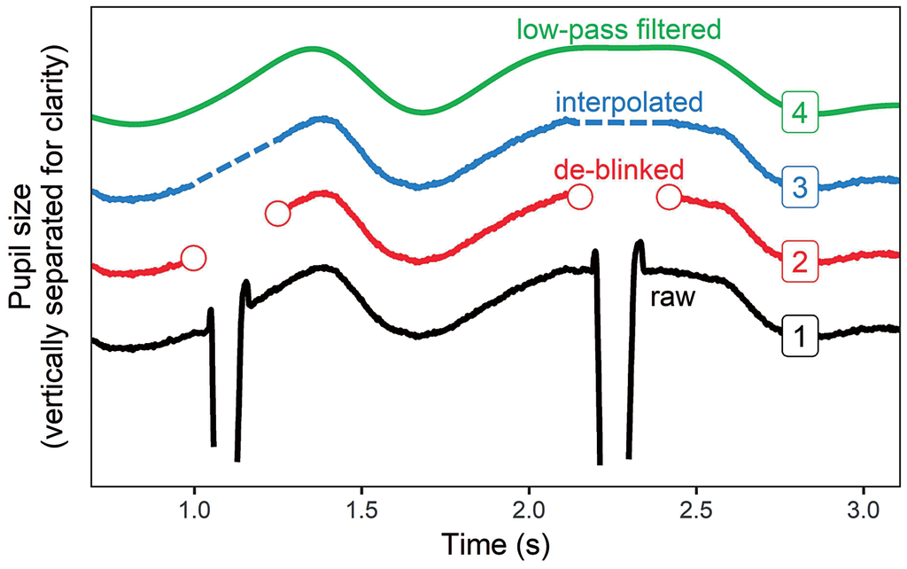

From Winn et al., 2018

## Packages

```r
# Packages used
library(data.table) # data reading and manipulation
library(dplyr)      # data manipulation and pipe
library(ggplot2)    # visualization
library(signal)     # low-pass filtering
library(zoo)        # linear interpolation
library(imputeTS)   # linear interpolation
```

## Helper Functions

Functions used to downsample the data, extend blinks and merge pupil data files

```r
downSampleHalf <- function(inData, repeatNumb) {
  # function that removes every second row for a given number of repetition
  # takes in a data table and an integer of the number or halving
  for (i in 1:repeatNumb){
    toDelete <- seq(1, nrow(inData), 2) # by half
    inData <- inData[ toDelete ,]
  }
  return(inData)
}

extendBlinks <- function(data,dur) {
  # function for extending blinks before and after blink
  # this is to account for distortion caused by blinking
  # takes in a data table with a column named "isBlink" and
  # an integer for the number of samples to extend the blink
  tempDat <- data
  maxRow <- nrow(data)
  for (i in as.array(which(data$isBlink == 1))) {
    # 50 accounts for the number of rows within 100ms at a 500Hz sampleing rate
    if ((i - dur) > 0) {
      if (data$isBlink[i-1] == 0) {
        tempDat$isBlink[(i-dur):i] <- 1
      }
    }
    if ((i + dur) <= maxRow) {
      if (data$isBlink[i+1] == 0) {
        tempDat$isBlink[i:(i+dur)] <- 1
      }
    }
    if ((i + dur) > maxRow){
      tempDat$isBlink[i:maxRow] <- 1
    }
  }
  return(tempDat)
}

mergeEye <- function(){
  # function for mergeing the pupil data .csv files
  for (part in 0:7){
    for (sess in 0:2){
      i <- as.character(part)
      j <- as.character(sess)
      eyeFileName = paste('data/eyeDataProcessed/00',i,"_",j,"EyeV3.csv",sep="")
      if (file.exists(eyeFileName) == T) {
        print(eyeFileName)
        tempDF <- fread(eyeFileName)
        if (part == 0 & sess == 0) {
          mainDF <- tempDF
        } else {
          mainDF <- rbind(mainDF, tempDF)
        }
      }
    }
  }
  return(mainDF)
}
```

## Overview

- Loop over participants
  - Loop over sessions
    - Import Pupil Data (participant:session)
    - Import Behavioral Data (participant:session)
    - Keep only needed columns from pupil data
    - Compute the pupil diameter (average of left and right pupil)
    - Label blink and non-tracked samples
    - Remove un-needed columns
    - Extend blinks (100ms)
    - Set pupil diameter to NA for blink samples
    - Linear interpolation
    - Low-pass filtering
    - Lebeling trials, blocks and sessions on pupil data
    - Remove samples with no labels
    - Add other useful labels (error/surprise/contingent/reliability condition)
    - Down-sample to 62.5Hz
    - Zeroing timestamps
      - Session
      - Trial
      - Section
  - Export Data
- Merge all pupil data files

## Complete Code

```r
# setting parameters for a low-pass 4th order butterfill filter at 4Hz
bfLow <- signal::butter(4, 0.04, type="low")

# loop over participants
for (part in 0:7){
  # loop over sessions
  for (sess in 0:2){


    i <- as.character(part)
    j <- as.character(sess)
    eyeFileName = paste('data/eyeDataRawFixed/00',i,"_",j,"EyeDataV2.csv",sep="")
    summFileName = paste('data/summDataFixed/00',i,"_",j,"SummDataV2.csv",sep="")
    if (file.exists(eyeFileName) == T & file.exists(summFileName) == T){
      print(paste(i,j,sep = '_'))


      # import datas
      eyeDat <- data.table::fread(eyeFileName)
      summDat <- data.table::fread(summFileName)


      # label partID and session numb
      eyeDat$partID <- part
      eyeDat$session <- sess


      # keep needed columns
      eyeDat <- eyeDat %>%
        dplyr::select(c(partID, session, Timestamp, PupilMajorAxis, PupilMajorAxisRight,
                        Tracked, TrackedRight, GazeX, GazeY, GazeXRight, GazeYRight))


      # compute average pupil size
      eyeDat$pupilAvg <- (eyeDat$PupilMajorAxis + eyeDat$PupilMajorAxisRight) / 2


      # label blinks and non-tracks
      eyeDat$isBlink[eyeDat$Tracked == 0 | eyeDat$TrackedRight == 0] <- 1
      eyeDat$isBlink[is.na(eyeDat$isBlink)] <- 0


      # remove un-needed columns
      eyeDat <- eyeDat %>%
        dplyr::select(-c(Tracked, TrackedRight, PupilMajorAxis, PupilMajorAxisRight))


      # extend blinks
      eyeDat <- extendBlinks(eyeDat, 50)


      # set pupil diameter to NA on blinks
      eyeDat$pupilAvg[eyeDat$isBlink == T] <- NA


      # linear interpolation of NA pupil dilations
      eyeDat$pupilAvg <- imputeTS::na_interpolation(eyeDat$pupilAvg, "linear")
      eyeDat$pupilAvg <- zoo::na.fill(eyeDat$pupilAvg, "extend")
        # zoo::na.fill function extends the interpolation to the ends of the data


      # apply low-pass filter
      eyeDat$pupilAvg <- signal::filter(bfLow, eyeDat$pupilAvg)


      # loop for labeling trials, blocks and sections
      for (row in 1:nrow(summDat)){
        #label trial numb
        if (row == nrow(summDat)){
          eyeDat$trialTotal[eyeDat$Timestamp >= summDat$pointsStartTime[row] &
                              eyeDat$Timestamp <= summDat$feedbackEndTime[row]] <-
            summDat$trialTotal[row]
        } else{
          eyeDat$trialTotal[eyeDat$Timestamp >= summDat$pointsStartTime[row] &
                              eyeDat$Timestamp < summDat$pointsStartTime[row + 1]] <-
            summDat$trialTotal[row]
        }


        # label sections
        eyeDat$section[eyeDat$Timestamp >= summDat$pointsStartTime[row] &
                         eyeDat$Timestamp <= summDat$stimStartTime[row]] <- 0
        eyeDat$section[eyeDat$Timestamp >= summDat$stimStartTime[row] &
                         eyeDat$Timestamp <= summDat$respStartTime[row]] <- 1
        eyeDat$section[eyeDat$Timestamp >= summDat$respStartTime[row] &
                         eyeDat$Timestamp <= summDat$fixStartTime[row]] <- 2
        eyeDat$section[eyeDat$Timestamp >= summDat$fixStartTime[row] &
                         eyeDat$Timestamp <= summDat$feedbackStartTime[row]] <- 3
        eyeDat$section[eyeDat$Timestamp >= summDat$feedbackStartTime[row] &
                         eyeDat$Timestamp <= summDat$feedbackEndTime[row]] <- 4
      }


      # remove non sections
      eyeDat <- eyeDat %>%
        dplyr::filter(!is.na(section))


      # label blocks
      for (t in 0:191){
        eyeDat$blockNumb[eyeDat$trialTotal == t] <-
          summDat$block[summDat$trialTotal == t]
      }


      # loop for making useful labels
      for (trial in 0:191){

        # label prediction error state
        eyeDat$isCorrect[eyeDat$trialTotal == trial] <-
          summDat$isCorrect[summDat$trialTotal == trial]

        # label surprise type
        eyeDat$surpriseType[eyeDat$trialTotal == trial] <-
          summDat$surpriseType[summDat$trialTotal == trial]

        # label contingent condition
        eyeDat$contingentCond[eyeDat$trialTotal == trial] <-
          summDat$contingentCond[summDat$trialTotal == trial]

        # label reliability condition
        eyeDat$probCond[eyeDat$trialTotal == trial] <-
          summDat$probCond[summDat$trialTotal == trial]
      }


      # downsample to 62.5Hz
      eyeDat <- downSampleHalf(eyeDat,3)


      # zeroing timestamps
      # for whole session
      eyeDat$Timestamp <- eyeDat$Timestamp - eyeDat$Timestamp[1]

      # for each trial
      for (t in 0:191){
        eyeDat$trialTimestamp[eyeDat$trialTotal == t] <-
          eyeDat$Timestamp[eyeDat$trialTotal == t] - eyeDat$Timestamp[eyeDat$trialTotal == t][1]

        # for each section
        for (sec in 0:4){
          eyeDat$secTimestamp[eyeDat$trialTotal == t & eyeDat$section == sec] <-
            eyeDat$Timestamp[eyeDat$trialTotal == t & eyeDat$section == sec] -
            eyeDat$Timestamp[eyeDat$trialTotal == t & eyeDat$section == sec][1]
        }
      }


      # output the finished pupil data as csv
      outFileName = paste('data/eyeDataProcessed/00',i,"_",j,"EyeV3.csv",sep="")
      data.table::fwrite(eyeDat, outFileName)
    }
  }
}

# Once all pupil data has been preprocessed, we merge them into one.
mergedPupilData <- mergeEye()

# This merged data can than be exported as its own csv file
data.table::fwrite(mergedPupilData, "data/eyeMergeData.csv")
```

## Demonstration

The above code is the omnibus of all the steps taken during the preprocessing stage and it does not illustrate each stage of the pupil preposessing alone.  
The following codes and figures isolates each preporcessing steps.

### Raw Data

First we illustrate how the raw data looks like:

```r
# import data with labels and timestamps but no pupil preprocessing
dat1 <- data.table::fread("data/000_0EyePreProcDemo.csv")
# convert timestamp to seconds
dat1$ts <- dat1$trialTimestamp/1000000

# plot line graph of part of trial #100
p1 <- dat1[dat1$trialTotal==100] %>%
  ggplot(aes(x=ts,y=pupilAvg,color=factor(isBlink)))+
  geom_line(aes(group=1))+
  ylim(2,NA)+
  xlim(4.4,6)+
  ylab("Mean Pupil Diameter (mm)")+
  xlab("Timestamp (s)")+
  ggtitle("Raw")

# zoomed in verison of the above plot
p1v2 <- dat1[dat1$trialTotal==100] %>%
  ggplot(aes(x=ts,y=pupilAvg,color=factor(isBlink)))+
  geom_line(aes(group=1))+
  ylim(3.9,NA)+
  xlim(4.4,6)+
  ylab("Mean Pupil Diameter (mm)")+
  xlab("Timestamp (s)")+
  ggtitle("Raw")
```

We can see a gap around the 5 second and 5.6 second mark where the blink has occured. Samples identified as blinks are colored blue. However, this is not visible in the second zoomed in plot.

#### Zoomed out

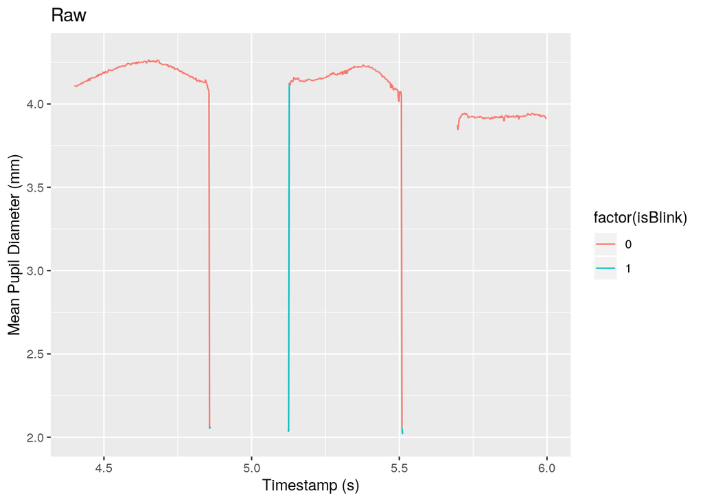

#### Zoomed in

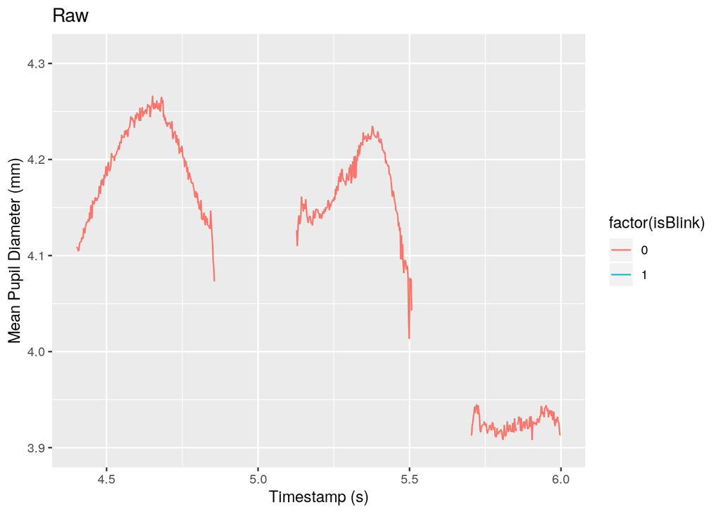

### Blink Extension

Next, we will extend the blinks to occupy 100ms before and after the already identified blink samples.

```r
# extend the blinks by 50 samples
# since our data has a sampling rate of 500Hz, 50 samples translates to 100ms.
dat2 <- extendBlinks(dat1[dat1$trialTotal==100],50)
p2 <- dat2 %>%
  ggplot(aes(x=ts,y=pupilAvg,color=factor(isBlink)))+
  geom_line(aes(group=1))+
  ylim(2,NA)+
  xlim(4.4,6)+
  ylab("Mean Pupil Diameter (mm)")+
  xlab("Timestamp (s)")+
  ggtitle("Blink Extension")

# zoomed in version of the first plot
p2v2 <- dat2 %>%
  ggplot(aes(x=ts,y=pupilAvg,color=factor(isBlink)))+
  geom_line(aes(group=1))+
  ylim(3.9,NA)+
  xlim(4.4,6)+
  ylab("Mean Pupil Diameter (mm)")+
  xlab("Timestamp (s)")+
  ggtitle("Blink Extension")
```

[output not shown]

#### Zoomed out

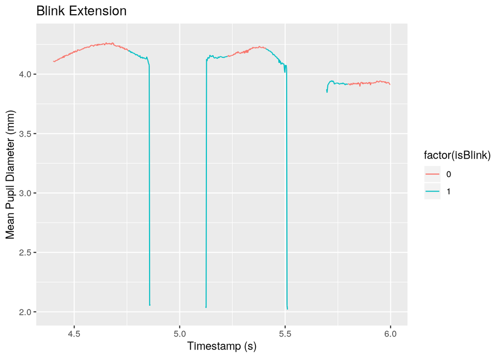

### Blink Sample Removal

Next, we set the pupil diameter value to to NA for all samples labeled as blinks.

```r
dat3 <- dat2
dat3$pupilAvg[dat3$isBlink == T] <- NA

p3 <- dat3 %>%
  ggplot(aes(x=ts,y=pupilAvg,color=factor(isBlink)))+
  geom_line(aes(group=1))+
  ylim(3.9,NA)+
  xlim(4.4,6)+
  ylab("Mean Pupil Diameter (mm)")+
  xlab("Timestamp (s)")+
  ggtitle("Blink Sample Removal")
```

[output not shown]

### Linear Interpolation

```r
# interpolation
dat3$pupilAvg <- imputeTS::na_interpolation(dat3$pupilAvg, "linear")
# this step is only necessary to interpolate samples at the ends of the data
dat3$pupilAvg <- zoo::na.fill(dat3$pupilAvg, "extend")

p4 <- dat3 %>%
  ggplot(aes(x=ts,y=pupilAvg,color=factor(isBlink)))+
  geom_line(aes(group=1))+
  ylim(3.9,NA)+
  xlim(4.4,6)+
  ylab("Mean Pupil Diameter (mm)")+
  xlab("Timestamp (s)")+
  ggtitle("Linear Interpolation")
```

[output not shown]

### Low-pass Filter

With interpolation done, we will now apply a low-pass filter.  
In our case, we will apply a fourth order butterfill low-pass filter at 4Hz.

```r
dat4 <- dat3

# setting parameters for a fourth order low-pass butterfill filter at 4Hz
# parameter from left to right: number of order, frequency, type of filter.
bfLow <- signal::butter(4, 0.04, type="low")

# apply low-pass filter
dat4$pupilAvg <- signal::filter(bfLow, dat3$pupilAvg)

p5 <- dat4 %>%
  ggplot(aes(x=ts,y=pupilAvg,color=factor(isBlink)))+
  geom_line(aes(group=1))+
  ylim(3.9,4.3)+
  xlim(4.4,6)+
  ylab("Mean Pupil Diameter (mm)")+
  xlab("Timestamp (s)")+
  ggtitle("Low-Pass Filter")
```

With the low-pass filtering done, we have not completed the preprocessing of our pupil data. With this, we can now commence analysis of the pupil data.

#### After

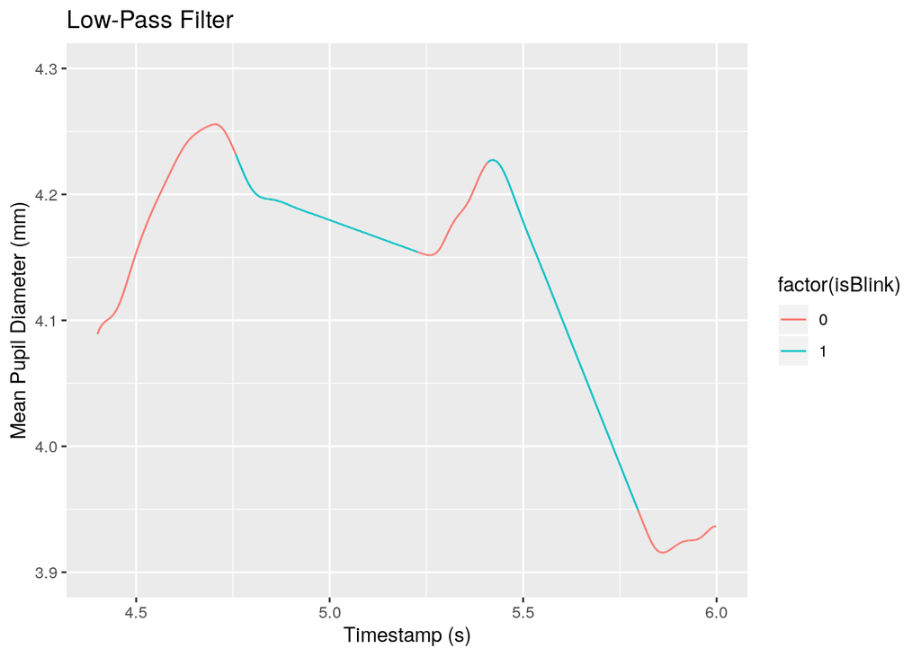

### Down Sampling

In my case, I decided to down sample the data to be about 62.5Hz to make my analysis to be more expedient and since 500Hz is far more samples than what is necessary.

```r
# removes every other sample three times over
dat5 <- downSampleHalf(dat4,3)

# Number of samples per trial before down sampling
nrow(dat4)
```

```
## [1] 6559
```

```r
# Number of samples per trial after down sampling
nrow(dat5)
```

```
## [1] 820
```

```r
p6 <- dat5 %>%
  ggplot(aes(x=ts,y=pupilAvg,color=factor(isBlink)))+
  geom_point(aes(group=1), size = 0.5)+
  ylim(3.9,4.3)+
  xlim(4.4,6)+
  ylab("Mean Pupil Diameter (mm)")+
  xlab("Timestamp (s)")+
  ggtitle("Down Sampled")

p6v2 <- dat4 %>%
  ggplot(aes(x=ts,y=pupilAvg,color=factor(isBlink)))+
  geom_point(aes(group=1), size = 0.5)+
  ylim(3.9,4.3)+
  xlim(4.4,6)+
  ylab("Mean Pupil Diameter (mm)")+
  xlab("Timestamp (s)")+
  ggtitle("Not Down Sampled (samples are too numerous to discern individual points)")
```

The number of samples in my downsampled trial is about 8 times smaller than the original trial data. And it is unlikely for you to differentiate the plots visually (the first plot is from the down sampled data).

#### After

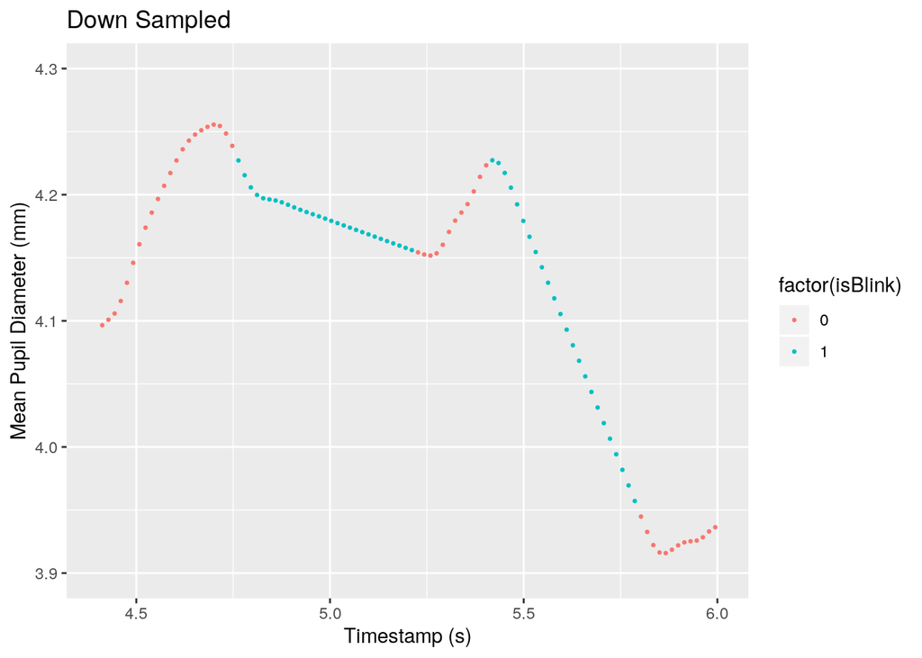

#### Before

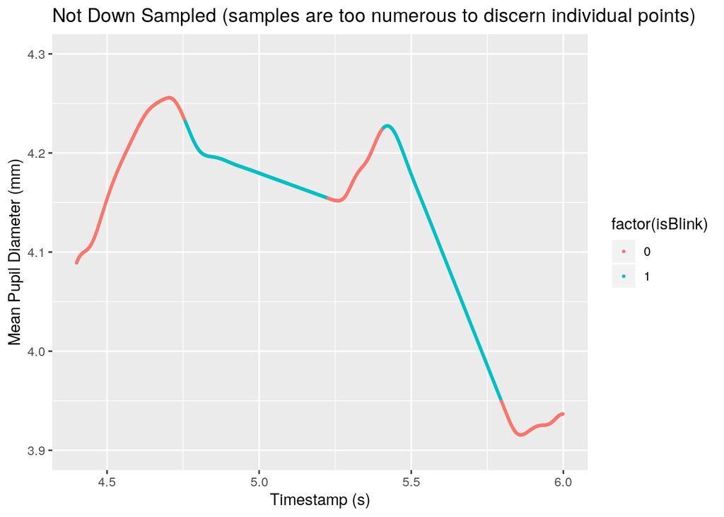

### Demonstration Plots Overview

Here is an overview of all the plots.

#### Raw

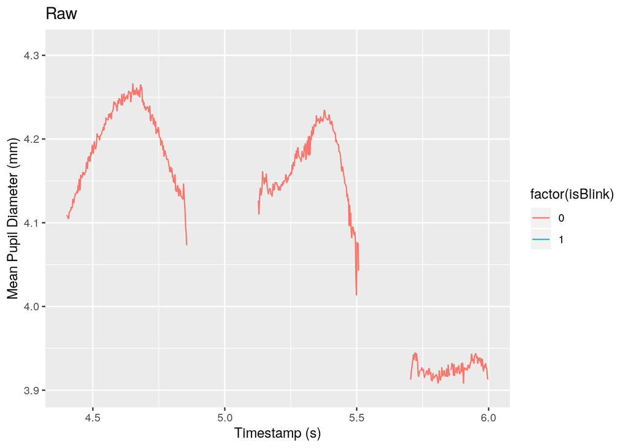

#### Low-Pass Filter

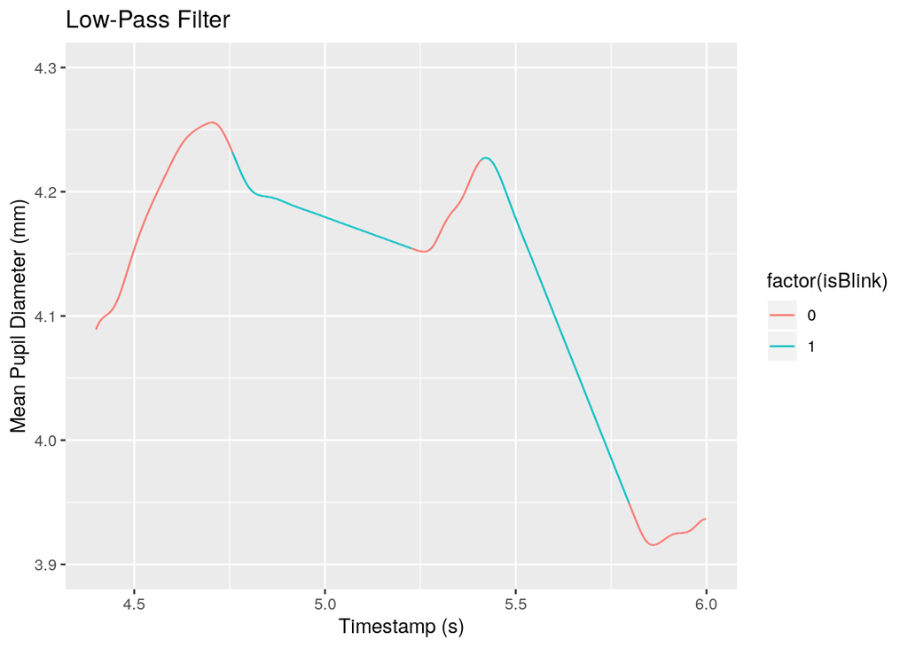

#### Down Sample

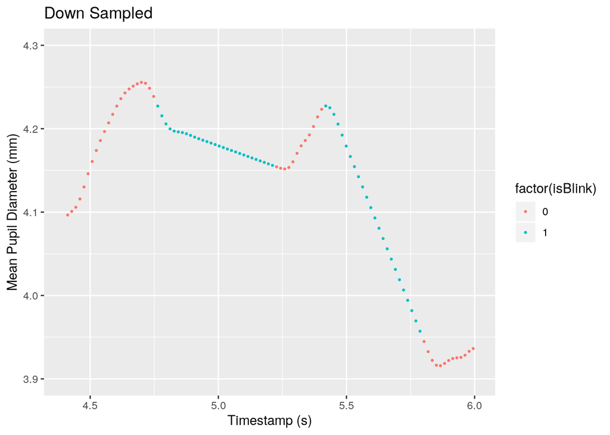